# Final Project

Alex Pongchit

5/18/2020

## Video Game Sales

The video game industry is the largest entertainment industry in the world. Looking at a list of video game sales from various years could help up determine why this industry is so profitable.

## Data Curation

First we must find a dataset to use in our analysis. The dataset I will be using: https://www.kaggle.com/gregorut/videogamesales

```r
video_game_tab <- read.csv("/Users/apongchit/Downloads/vgsales.csv")

video_game_tab$Year <- as.POSIXct(strptime(video_game_tab$Year, format='%Y'))

head(video_game_tab)
```

```
##   Rank                     Name Platform       Year        Genre Publisher
## 1    1               Wii Sports      Wii 2006-05-18       Sports  Nintendo
## 2    2        Super Mario Bros.      NES 1985-05-18     Platform  Nintendo
## 3    3           Mario Kart Wii      Wii 2008-05-18       Racing  Nintendo
## 4    4        Wii Sports Resort      Wii 2009-05-18       Sports  Nintendo
## 5    5 Pokemon Red/Pokemon Blue       GB 1996-05-18 Role-Playing  Nintendo
## 6    6                   Tetris       GB 1989-05-18       Puzzle  Nintendo
##   NA_Sales EU_Sales JP_Sales Other_Sales Global_Sales
## 1    41.49    29.02     3.77        8.46        82.74
## 2    29.08     3.58     6.81        0.77        40.24
## 3    15.85    12.88     3.79        3.31        35.82
## 4    15.75    11.01     3.28        2.96        33.00
## 5    11.27     8.89    10.22        1.00        31.37
## 6    23.20     2.26     4.22        0.58        30.26
```

## Analysis

Now that we have a clean dataset, we can begin our analysis.

First, we could look at if there is a relationship between a game publisher and the game’s sales in North America (in millions.) from the top 100 selling games.

```r
library(dplyr)
```

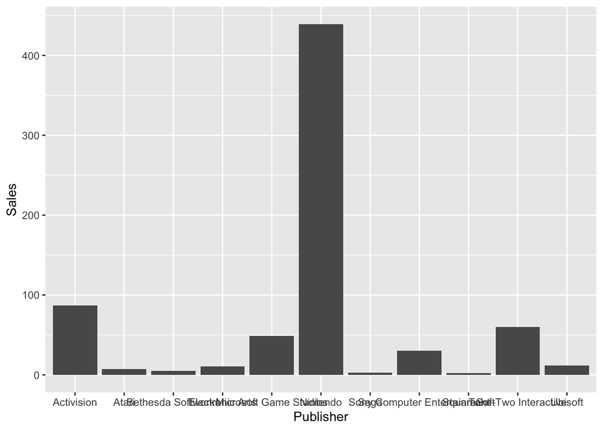

```r
library(ggplot2)
library(sqldf)
publisher_sales = sqldf("select Publisher, sum(NA_Sales) as Sales from video_game_tab where Rank <= 100 group by Publisher")

publisher_sales %>%
  ggplot(aes(x = Publisher, y = Sales)) +
  geom_bar(stat = "identity")
```

Secondly, we could look at if there is a relationship between genre and the game’s sales in North America (in millions).

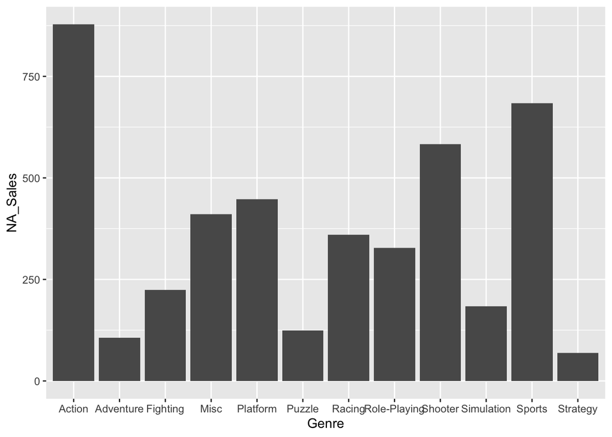

```r
library(ggplot2)


ggplot(video_game_tab, aes(x = Genre, y = NA_Sales)) + geom_bar(stat = "identity")
```

After examining both bar graphs, we can see that Nintendo has the highest sales out of all the publishers in North America. We can also see that the action genre has the highest sales out of all the genres in North America. What’s interesting to note is that Nintendo isn’t known for making action games. Some of their best selling products are games such as Mario and Wii Sports. One reason for this could be because Nintendo has been making games for over 30 years. This means that older and younger genrations have had a chance to play their games which means that they have high exposure to a larger audience. This makes sense for their high amount of sales. On other note, it would make sense that action games have the highest sales out of any genre. The action genre is the most popular genre which again means that it has a larger audience that in turn will have higher sales.

Another area we can examine is the relationship between year and sales. Again, sales are in millions.

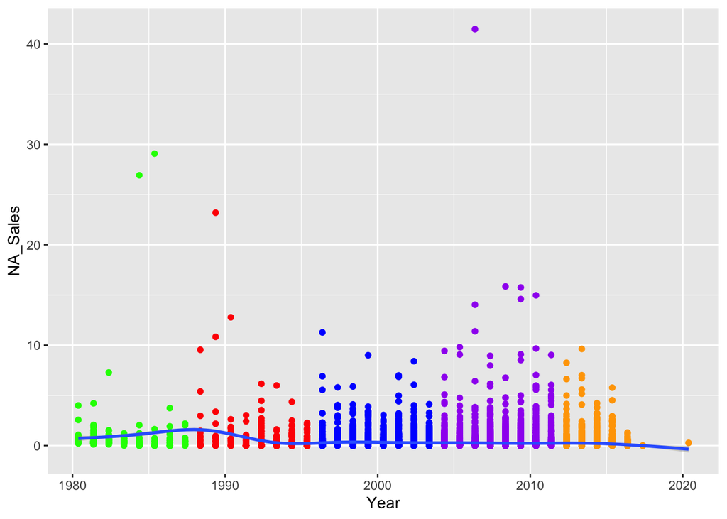

```r
# splits the data into different year ranges
range <- mutate(video_game_tab, Year_Range = cut(Year, breaks=5))
range <- split(range, range$Year_Range)

# this plot will reveal any outliers
ggplot() +
  geom_point(data = range[[1]], aes(x = Year, y = NA_Sales), color='green') +
  geom_point(data = range[[2]], aes(x = Year, y = NA_Sales), color='red') +
  geom_point(data = range[[3]], aes(x = Year, y = NA_Sales), color='blue') +
  geom_point(data = range[[4]], aes(x = Year, y = NA_Sales), color='purple') +
  geom_point(data = range[[5]], aes(x = Year, y = NA_Sales), color='orange') +
  geom_smooth(data = video_game_tab, aes(x = Year, y = NA_Sales))
```

# Conclusion